# White Wine EDA Analysis

# Multivariate Analysis

### Interesting or Surprising Interactions Between Features?

# Final Plots and Summary

### Wine Quality Scores

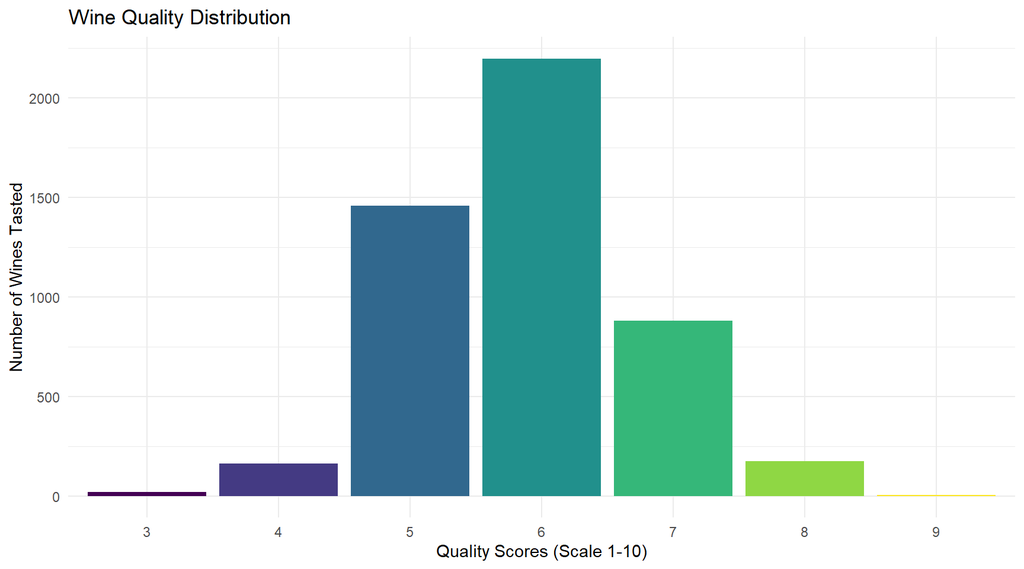

### Relationship Between Alcohol and Ratings

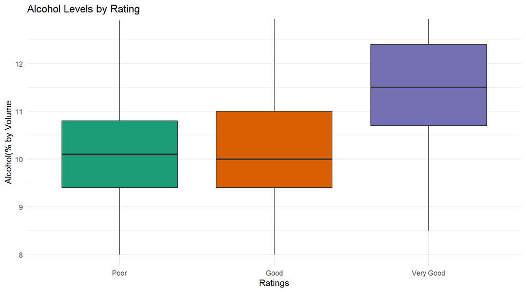

White wines with higher alcohol by volume generally received a better rating than wines with less alcohol content

### Residual Sugar and Density by Quality Score and Rating

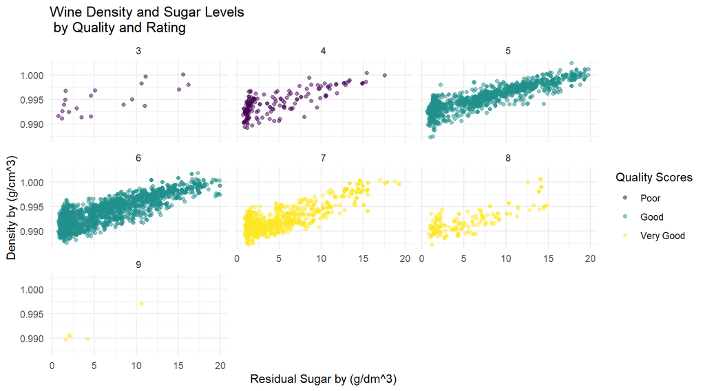

This positive correlation suggests residual sugar contributes to a change in density. The density increases when there is more residual sugars in the wine. However, it is still unclear as to whether these attributes directly impact quality and ratings. Although the “Very Good” wines with a quality score of 9 have less than 15 g/dm^3 of residual sugar and are less dense than water, so are other wines with lower ratings and quality scores.

# Reflection

After exploring various attributes of white wine, it can be seen that there are some strong relationships between different chemicals. While trying to pinpoint what makes a great wine, the relationships are not as clear. Tastes in wine may be dependent upon the person doing the tasting. Some of the same attributes that made a wine of good quality were also seen in poorer quality wines. No perfect combination was found through this analysis. Perhaps if the data had columns for what each expert scored the wine, more insights could have been made as to their individual tastes. That in comparison to the average score would allow us to see if the overall score was in fact a fair representation. If two experts gave a wine a score of 10 but, the third expert gave the wine a score of 1, the average score would be a 7. This would then inadvertently change the results of analysis on the data when looking for a high quality wine. Averages, in this case, do not tell the whole story.

In future explorations, more multivariate exploration with the chemical make up the wines could reveal more information about a high quality wine but, the results from this analysis were too scattered to know for certain. In addition, obtaining further information about what comprises making white wines or wines in general may have been helpful when comparing chemical components with one another.

# Resources

- http://www.sthda.com/english/wiki/correlation-matrix-a-quick-start-guide-to-analyze-format-and-visualize-a-correlation-matrix-using-r-software
- [https://www.stat.cmu.edu/~cshalizi/rmarkdow/#code-chunks-and-their-results](https://www.stat.cmu.edu/~cshalizi/rmarkdown/#code-chunks-and-their-results)
- https://www.usgs.gov/special-topic/water-science-school/science/water-density
- https://www.datanovia.com/en/blog/top-r-color-palettes-to-know-for-great-data-visualization/